# Kaggle AmesHousing

Vilhelm Stiernstedt

18/02/2018

## Dataset Introduction

The experimental dataset used is the Ames House Price Dataset. It includes 79 explanatory variables of residential homes. For more details on the dataset and the competition see https://www.kaggle.com/c/house-prices-advanced-regression-techniques.

## Project Goal

- Predict the final price of each home with the lowest RMSE score possible by novel feature engineering and general linear regression models inc. Ridge, Lasso and ElasticNet model techniques.

## Data Ingestion & Cleaning

In this section we will ingest, inspect and clean data. Cleaning process includes: 1) Dropping uninformative features  
2) Refactorize known features 3) Dropping low level features 4) NA imputation -> by using data description notes, data analysis and LM for prediction.

```r
### Data Ingestion ----

### Data Ingestion
dt_train <- data.table(read.csv("train.csv"))
dt_test <- data.table(read.csv("test.csv"))

# ---- Initial Data Inspection ----
### Columns same for Test and Train data
colnames(dt_train)
```

```
##  [1] "Id"            "MSSubClass"    "MSZoning"      "LotFrontage"
##  [5] "LotArea"       "Street"        "Alley"         "LotShape"
##  [9] "LandContour"   "Utilities"     "LotConfig"     "LandSlope"
## [13] "Neighborhood"  "Condition1"    "Condition2"    "BldgType"
## [17] "HouseStyle"    "OverallQual"   "OverallCond"   "YearBuilt"
## [21] "YearRemodAdd"  "RoofStyle"     "RoofMatl"      "Exterior1st"
## [25] "Exterior2nd"   "MasVnrType"    "MasVnrArea"    "ExterQual"
## [29] "ExterCond"     "Foundation"    "BsmtQual"      "BsmtCond"
## [33] "BsmtExposure"  "BsmtFinType1"  "BsmtFinSF1"    "BsmtFinType2"
## [37] "BsmtFinSF2"    "BsmtUnfSF"     "TotalBsmtSF"   "Heating"
## [41] "HeatingQC"     "CentralAir"    "Electrical"    "X1stFlrSF"
## [45] "X2ndFlrSF"     "LowQualFinSF"  "GrLivArea"     "BsmtFullBath"
## [49] "BsmtHalfBath"  "FullBath"      "HalfBath"      "BedroomAbvGr"
## [53] "KitchenAbvGr"  "KitchenQual"   "TotRmsAbvGrd"  "Functional"
## [57] "Fireplaces"    "FireplaceQu"   "GarageType"    "GarageYrBlt"
## [61] "GarageFinish"  "GarageCars"    "GarageArea"    "GarageQual"
## [65] "GarageCond"    "PavedDrive"    "WoodDeckSF"    "OpenPorchSF"
## [69] "EnclosedPorch" "X3SsnPorch"    "ScreenPorch"   "PoolArea"
## [73] "PoolQC"        "Fence"         "MiscFeature"   "MiscVal"
## [77] "MoSold"        "YrSold"        "SaleType"      "SaleCondition"
## [81] "SalePrice"
```

```r
colnames(dt_test) # test data missing SalePrice as assumed
```

```
##  [1] "Id"            "MSSubClass"    "MSZoning"      "LotFrontage"
##  [5] "LotArea"       "Street"        "Alley"         "LotShape"
##  [9] "LandContour"   "Utilities"     "LotConfig"     "LandSlope"
## [13] "Neighborhood"  "Condition1"    "Condition2"    "BldgType"
## [17] "HouseStyle"    "OverallQual"   "OverallCond"   "YearBuilt"
## [21] "YearRemodAdd"  "RoofStyle"     "RoofMatl"      "Exterior1st"
## [25] "Exterior2nd"   "MasVnrType"    "MasVnrArea"    "ExterQual"
## [29] "ExterCond"     "Foundation"    "BsmtQual"      "BsmtCond"
## [33] "BsmtExposure"  "BsmtFinType1"  "BsmtFinSF1"    "BsmtFinType2"
## [37] "BsmtFinSF2"    "BsmtUnfSF"     "TotalBsmtSF"   "Heating"
## [41] "HeatingQC"     "CentralAir"    "Electrical"    "X1stFlrSF"
## [45] "X2ndFlrSF"     "LowQualFinSF"  "GrLivArea"     "BsmtFullBath"
## [49] "BsmtHalfBath"  "FullBath"      "HalfBath"      "BedroomAbvGr"
## [53] "KitchenAbvGr"  "KitchenQual"   "TotRmsAbvGrd"  "Functional"
## [57] "Fireplaces"    "FireplaceQu"   "GarageType"    "GarageYrBlt"
## [61] "GarageFinish"  "GarageCars"    "GarageArea"    "GarageQual"
## [65] "GarageCond"    "PavedDrive"    "WoodDeckSF"    "OpenPorchSF"
## [69] "EnclosedPorch" "X3SsnPorch"    "ScreenPorch"   "PoolArea"
## [73] "PoolQC"        "Fence"         "MiscFeature"   "MiscVal"
## [77] "MoSold"        "YrSold"        "SaleType"      "SaleCondition"
```

```r
length(dt_train$Id) == nrow(dt_train) # all rows unique Id thuis no duplicates and Id can be dropped
```

```
## [1] TRUE
```

```r
### Drop Columns
dt_train$Id <- NULL

# Merge test and training data
dt_All <- rbind(dt_train[, !"SalePrice"], dt_test[, !"Id"])

# ---- Variable Identification ----
table(sapply(dt_train, class))
```

```
##
##  factor integer
##      43      37
```

```r
table(sapply(dt_test, class))
```

```
##
##  factor integer
##      43      37
```

```r
# ---- Refactorize Known Features ----
### Change class of variables
# MSSubClass: The building class -> not numerical -> factor
dt_train[, MSSubClass := as.factor(MSSubClass)]
dt_test[, MSSubClass := as.factor(MSSubClass)]

# MoSold: Month Sold -> not numerical -> factor
dt_train[, MoSold := as.factor(MoSold)]
dt_test[, MoSold := as.factor(MoSold)]

# --- Factor Level Anlysis ----
### Get Factor variables from training split
train_factor_columns <- names(which(sapply(dt_train, is.factor)))
test_factor_columns <- names(which(sapply(dt_test, is.factor)))
### Show number of factor levels per variable
sort(sapply(lapply(dt_train[, train_factor_columns, with = F], droplevels), nlevels), decreasing = F)
```

```
##        Street         Alley     Utilities    CentralAir     LandSlope
##             2             2             2             2             3
##  GarageFinish    PavedDrive        PoolQC      LotShape   LandContour
##             3             3             3             4             4
##    MasVnrType     ExterQual      BsmtQual      BsmtCond  BsmtExposure
##             4             4             4             4             4
##   KitchenQual         Fence   MiscFeature      MSZoning     LotConfig
##             4             4             4             5             5
##      BldgType     ExterCond     HeatingQC    Electrical   FireplaceQu
##             5             5             5             5             5
##    GarageQual    GarageCond     RoofStyle    Foundation  BsmtFinType1
##             5             5             6             6             6
##  BsmtFinType2       Heating    GarageType SaleCondition    Functional
##             6             6             6             6             7
##    Condition2    HouseStyle      RoofMatl    Condition1      SaleType
##             8             8             8             9             9
##        MoSold    MSSubClass   Exterior1st   Exterior2nd  Neighborhood
##            12            15            15            16            25
```

```r
sort(sapply(lapply(dt_test[, test_factor_columns, with = F], droplevels), nlevels), decreasing = F)
```

```
##     Utilities        Street         Alley    CentralAir        PoolQC
##             1             2             2             2             2
##     LandSlope  GarageFinish    PavedDrive   MiscFeature      LotShape
##             3             3             3             3             4
##   LandContour      RoofMatl    MasVnrType     ExterQual      BsmtQual
##             4             4             4             4             4
##      BsmtCond  BsmtExposure       Heating    Electrical   KitchenQual
##             4             4             4             4             4
##    GarageQual         Fence      MSZoning     LotConfig    Condition2
##             4             4             5             5             5
##      BldgType     ExterCond     HeatingQC   FireplaceQu    GarageCond
##             5             5             5             5             5
##     RoofStyle    Foundation  BsmtFinType1  BsmtFinType2    GarageType
##             6             6             6             6             6
## SaleCondition    HouseStyle    Functional    Condition1      SaleType
##             6             7             7             9             9
##        MoSold   Exterior1st   Exterior2nd    MSSubClass  Neighborhood
##            12            13            15            16            25
```

```r
### Utilites -> remove all properties that doesn't have all public utilities -> only one reaming -> drop feature
dt_train$Utilities <- NULL
dt_test$Utilities <- NULL

# --- Inspection of Noteworthy Variables ----
### MSZoning -> C (meaning commercial) properties?
summary(dt_train$MSZoning) # 10 commerical properties
```

```
## C (all)      FV      RH      RL      RM
##      10      65      16    1151     218
```

```r
summary(dt_test$MSZoning) # 15 commerical properties
```

```
## C (all)      FV      RH      RL      RM    NA's
##      15      74      10    1114     242       4
```

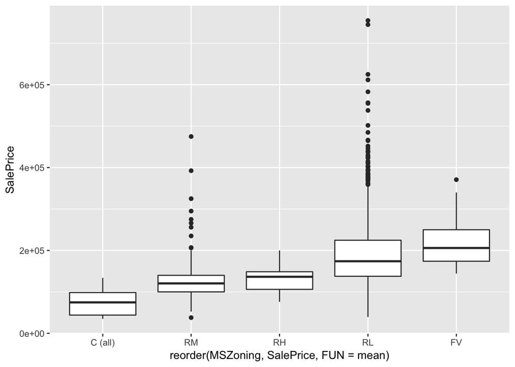

```r
# Plot relationship with SalePrice
ggplot(dt_train, aes(x = reorder(MSZoning, SalePrice, FUN = mean), y = SalePrice)) + geom_boxplot()
```

```r
# Mean price by type
dt_train[, mean(SalePrice), by = MSZoning]
```

```
##    MSZoning       V1
## 1:       RL 191005.0
## 2:       RM 126316.8
## 3:  C (all)  74528.0
## 4:       FV 214014.1
## 5:       RH 131558.4
```

```r
# Remove or keep? -> Keep, as it might be good regressor for test data.


# ---- Missing Values Treatment ----
# Count NAs per colums and subset for columns with NAs > 0
list_NAs <- sapply(dt_train, function(x) sum(is.na(x)))
list_NAs <- sort(list_NAs[list_NAs > 0], decreasing = T)
list_NAs
```

```
##       PoolQC  MiscFeature        Alley        Fence  FireplaceQu
##         1453         1406         1369         1179          690
##  LotFrontage   GarageType  GarageYrBlt GarageFinish   GarageQual
##          259           81           81           81           81
##   GarageCond BsmtExposure BsmtFinType2     BsmtQual     BsmtCond
##           81           38           38           37           37
## BsmtFinType1   MasVnrType   MasVnrArea   Electrical
##           37            8            8            1
```

```r
paste("Number of variables in training data that contains NA: ", ifelse(length(list_NAs)>0, length(list_NAs), 0))
```

```
## [1] "Number of variables in training data that contains NA:  19"
```

```r
# Save column names
NA_columns <- names(list_NAs)

# Check NAs for test data
list_NAs_test <- sapply(dt_test, function(x) sum(is.na(x)))
list_NAs_test <- sort(list_NAs_test[list_NAs_test > 0], decreasing = T)
list_NAs_test
```

```
##       PoolQC  MiscFeature        Alley        Fence  FireplaceQu
##         1456         1408         1352         1169          730
##  LotFrontage  GarageYrBlt GarageFinish   GarageQual   GarageCond
##          227           78           78           78           78
##   GarageType     BsmtCond     BsmtQual BsmtExposure BsmtFinType1
##           76           45           44           44           42
## BsmtFinType2   MasVnrType   MasVnrArea     MSZoning BsmtFullBath
##           42           16           15            4            2
## BsmtHalfBath   Functional  Exterior1st  Exterior2nd   BsmtFinSF1
##            2            2            1            1            1
##   BsmtFinSF2    BsmtUnfSF  TotalBsmtSF  KitchenQual   GarageCars
##            1            1            1            1            1
##   GarageArea     SaleType
##            1            1
```

```r
paste("Number of variables in test data that contains NA: ", ifelse(length(list_NAs_test)>0, length(list_NAs_test), 0))
```

```
## [1] "Number of variables in test data that contains NA:  32"
```

```r
### Treat NAs per variable
# LotFrontace (Linear feet of street connected to property)
summary(dt_train$LotFrontage) # -> Predict values based on LotArea, LotShape and neighbourhood
```

```
##    Min. 1st Qu.  Median    Mean 3rd Qu.    Max.    NA's
##   21.00   59.00   69.00   70.05   80.00  313.00     259
```

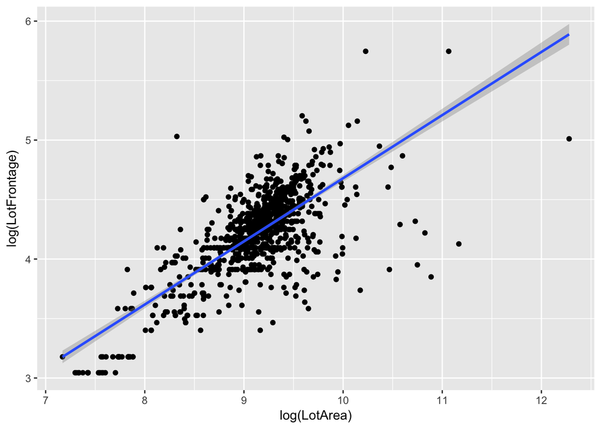

```r
# LotArea: Plot relationship -> Relationship analysis reveal log is optimal.
ggplot(dt_train, aes(x=log(LotArea), y=log(LotFrontage))) + geom_point() + geom_smooth(method=lm)
```